# Customizing Plots

We now know how to create many plot types using `ggplot2`, but often you want to customize your plots. Today, we’ll discuss common tools for customizing our plots.

To begin, make sure that you have the `tidyverse` loaded.

```r
library(tidyverse)
```

Also, let’s start with our plot from the exercise

```r
scorecard <- read_csv("https://github.com/cmsc205/data/raw/master/ScorecardSmallNarrow.csv")
```

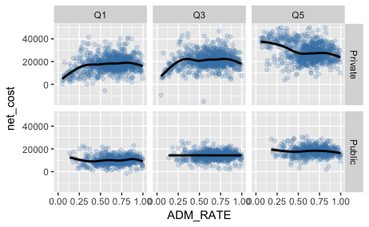

```r
# Code for your solution to the warm up exercise
# Let's assign the plot ot the object p
p <- scorecard %>%
  ggplot(aes(x = ADM_RATE, y = net_cost)) +
  geom_point(alpha = 0.2, color = "steelblue") +
  geom_smooth(color = "black", se = TRUE) +
  facet_grid(CONTROL ~ income_group)
p
```

# Adding titles, axis labels, and legend labels

Good labels are critical for making your plots accessible to a wider audience. It’s important to ensure axis and legend labels display the full variable name (or a logical abbreviaition), but this does not always happen by default.

To add/alter these annotations we simply add a new layer using the `labs` function.

#### Adding a title

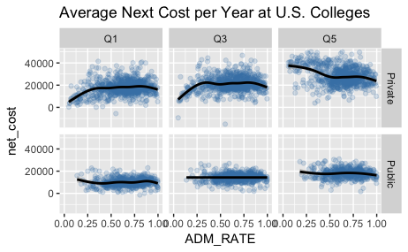

```r
# Code for adding a title to a plot
p <- p + labs(title = "Average Next Cost per Year at U.S. Colleges")
p
```

#### Adding a subtitle

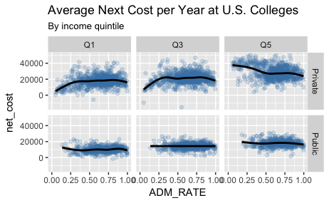

```r
# Code for adding a subtitle to a plot
p <- p + labs(subtitle = "By income quintile")
p
```

#### Changing the axis labels

```r
# Code to change axis labels
p <- p + labs(x = "Admissions rate, %",
         y = "Net cost per year, $'000")
```

#### Changing the legend labels

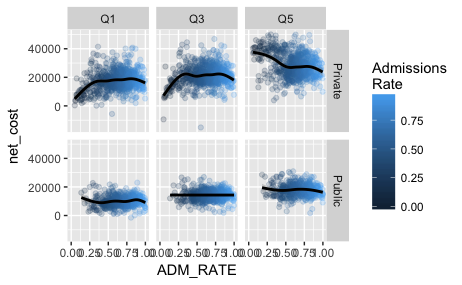

```r
# Code to change legend labels
scorecard %>%
  ggplot(aes(x = ADM_RATE, y = net_cost, color = ADM_RATE)) +
  geom_point(alpha = 0.2) +
  geom_smooth(color = "black", se = TRUE) +
  facet_grid(CONTROL ~ income_group) +
  labs(color = "Admissions\nRate")
```

# Ordering factors

Sometimes we need to order the levels of a factor to make a plot meaningful.

To examine this, let’s look at a new data set which contains informatio on the 10 most popular baby names in 2014.

```r
babynames <- read_csv("https://github.com/cmsc205/data/raw/master/top10babynames2014.csv")
```

[figure not shown]

```r
# Let's work with this bar chart of the top 10 baby names in 2014
babynames %>%
  ggplot(aes(x = name, y = n, fill = sex)) +
  geom_bar(stat = "identity") +
  coord_flip()
```

To do this with respect to another variable we can use the `reorder` function.

```r
# Reordering the names by popularity in the bar chart
babynames$name <- reorder(babynames$name,
                          FUN = function(x) -identity(x),
                          babynames$n)
p2 <- babynames %>%
  ggplot(aes(x = name, y = n, fill = sex)) +
  geom_bar(stat = "identity") +
  coord_flip() +
  labs(title = "Top 10 Baby Names in 2014",
       x = NULL,
       y = "Count")
```

# Choosing color palettes

`ggplot2` does not choose the nicest looking palettes, and the palettes are typically not colorblind friendly. Luckily, it’s quite easy to change the color palettes you use.

#### Manual adjustments

To manually adjust the colors we can use the functions `scale_color_manual` or `scale_fill_manual`

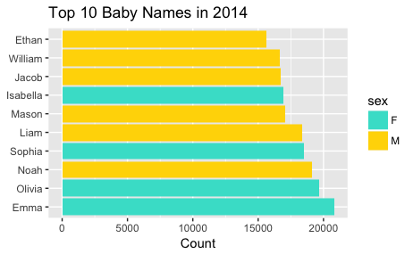

```r
# Code to manually adjust the plot colors
p2 + scale_fill_manual(values = c("turquoise", "gold"))
```

#### Using RColorBrewer

You can let the RColorBrewer package choose the colors for you using the `scale_color_brewer` and `scale_fill_brewer` functions.

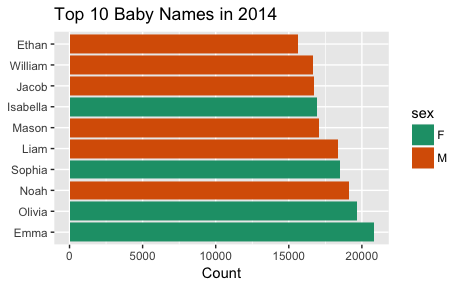

```r
# Code to use the scale_fill_brewer function
p2 + scale_fill_brewer(palette = "Dark2")
```

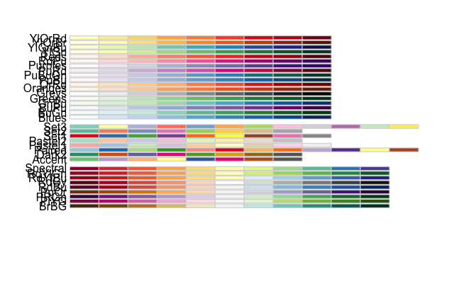

#### Using viridis

If you install the viridis package (this might not be on the server), then you can use the `scale_color_viridis` and `scale_fill_viridis` functions.

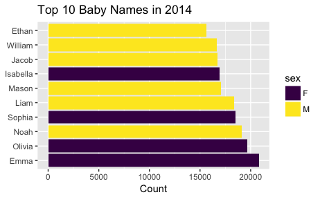

```r
# Example of how to use the viridis color scheme with a discrete variable
library(viridis)
p2 + scale_fill_viridis(discrete = TRUE)
```

#### A colorblind friendly palette

The `ggthemes` package contains a colorblind-friendly palette, which can be adopted using the `scale_color_colorblind` and `scale_fill_colorblind` functions.

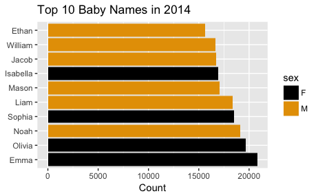

```r
# Using the colorblind friendly palette in ggthemes
library(ggthemes)
p2 + scale_fill_colorblind()
```

# Choosing themes

By default `ggplot2` uses a grey background and guidlines on a plot; however, we don’t always want our plots to appear this way. To change this the appearance, we need to work with themes.

The `ggthemes` package offers many additional [choices](https://github.com/jrnold/ggthemes).

We can use an existing theme just like adding a layer.

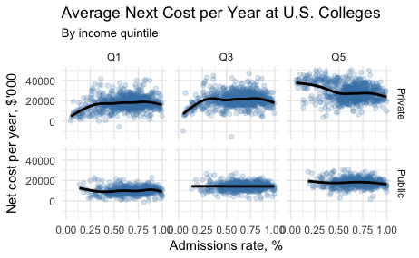

```r
# Let's check out the minimal theme first to remove many features
p + theme_minimal()
```

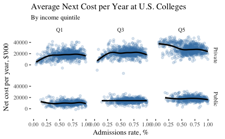

```r
# Let's pick another theme from the list
p + theme_tufte()
```

# Customizing themes

Sometimes the `ggthemes` package won’t do exactly what you want so you will have to dig into `ggplot2` a bit deeper and create your own theme.

See `?theme` for a list of all of the components that you can modify.